# KAGGLE PROJECT - HOUSE PREDICTION

### Cross-Validation

> Cross-Validating (70 to 30) and training the model on the train fold and validate or testing it on the validation fold.

```r
set.seed(124)
# Randomly sample 70% of the rows
index <- sample(x = 1:nrow(train), size = nrow(train)*.7, replace = F)
head(index) # These are row numbers
```

```
## [1] 1345  167 1002 1435  261  728
```

```r
# Subset train using the index to create train_fold
train_fold <- train[index, ]
# Subset the remaining row to create validation fold.
validation_fold <- train[-index, ]
```

> Now we get train_fold with 70% data and validation_fold with 30% data. Fit model with the train_fold and test it on the validation_fold.

> Let’s model the data using the variables or predictors described above.

```r
#model<-lm(log(SalePrice)~as.numeric(OverallQual)*factor(Neighborhood)+factor(KitchenQual)+log(`1stFlrSF`)*TotRmsAbvGrd+GrLivArea+GarageArea*GarageQual+MSSubClass+BsmtFullBath+log(LotArea)+Fireplaces+YearBuilt+Foundation+MasVnrArea+FullBath+Street*LandSlope+Functional+GarageFinish+Alley+CentralAir+Fence+BldgType,data=train_fold)
#summary(model)#  Reference Model
```

```r
# Building the model.

model<-   lm(log(SalePrice) ~ Neighborhood * OverallQual + log(GrLivArea) + TotalBsmtSF * `1stFlrSF` + MasVnrArea  + KitchenQual + Alley + MSZoning + Utilities + LotArea + OverallCond + BldgType+YearBuilt+FullBath  , data = train_fold)

summary(model) # Summary of the model.
```

```
##
## Call:
## lm(formula = log(SalePrice) ~ Neighborhood * OverallQual + log(GrLivArea) +
##     TotalBsmtSF * `1stFlrSF` + MasVnrArea + KitchenQual + Alley +
##     MSZoning + Utilities + LotArea + OverallCond + BldgType +
##     YearBuilt + FullBath, data = train_fold)
##
## Residuals:
##      Min       1Q   Median       3Q      Max
## -0.71545 -0.06348  0.00125  0.07004  0.39186
##
## Coefficients: (2 not defined because of singularities)
##                                   Estimate Std. Error t value Pr(>|t|)
## (Intercept)                     -1.245e+00  1.227e+00  -1.015 0.310491
## NeighborhoodBlueste              1.754e-01  2.018e-01   0.869 0.385061
## NeighborhoodBrDale               1.257e+00  1.068e+00   1.178 0.239231
## NeighborhoodBrkSide              1.038e+00  9.720e-01   1.067 0.286080
## NeighborhoodClearCr              1.100e+00  9.829e-01   1.119 0.263504
## NeighborhoodCollgCr              1.053e+00  9.702e-01   1.085 0.278002
## NeighborhoodCrawfor              9.376e-01  9.793e-01   0.957 0.338560
## NeighborhoodEdwards              1.233e+00  9.696e-01   1.272 0.203750
## NeighborhoodGilbert              1.186e+00  9.767e-01   1.215 0.224842
## NeighborhoodIDOTRR               1.006e+00  9.778e-01   1.029 0.303761
## NeighborhoodMeadowV              1.188e+00  1.006e+00   1.182 0.237675
## NeighborhoodMitchel              8.577e-01  9.828e-01   0.873 0.383002
## NeighborhoodNAmes                1.147e+00  9.702e-01   1.182 0.237345
## NeighborhoodNoRidge              4.812e-01  9.994e-01   0.481 0.630310
## NeighborhoodNPkVill              2.172e-01  1.613e-01   1.346 0.178499
## NeighborhoodNridgHt              6.925e-01  9.737e-01   0.711 0.477139
## NeighborhoodNWAmes               1.229e+00  9.834e-01   1.250 0.211660
## NeighborhoodOldTown              8.300e-01  9.696e-01   0.856 0.392203
## NeighborhoodSawyer               1.161e+00  9.831e-01   1.181 0.237842
## NeighborhoodSawyerW              9.025e-01  9.794e-01   0.921 0.357039
## NeighborhoodSomerst              9.527e-01  9.847e-01   0.967 0.333558
## NeighborhoodStoneBr             -2.261e-01  1.147e+00  -0.197 0.843867
## NeighborhoodSWISU                1.319e+00  9.788e-01   1.348 0.178013
## NeighborhoodTimber               8.370e-01  9.818e-01   0.853 0.394134
## NeighborhoodVeenker              6.377e-01  9.923e-01   0.643 0.520637
## OverallQual                      1.959e-01  1.365e-01   1.435 0.151603
## log(GrLivArea)                   4.262e-01  2.236e-02  19.059  < 2e-16 ***
```

[output cut: 37 more lines]

```
## NeighborhoodOldTown:OverallQual -1.051e-01  1.369e-01  -0.768 0.442768
## NeighborhoodSawyer:OverallQual  -1.711e-01  1.407e-01  -1.216 0.224289
## NeighborhoodSawyerW:OverallQual -1.185e-01  1.385e-01  -0.856 0.392421
## NeighborhoodSomerst:OverallQual -1.263e-01  1.383e-01  -0.913 0.361494
## NeighborhoodStoneBr:OverallQual  3.691e-02  1.564e-01   0.236 0.813485
## NeighborhoodSWISU:OverallQual   -1.932e-01  1.391e-01  -1.389 0.165137
## NeighborhoodTimber:OverallQual  -1.077e-01  1.382e-01  -0.779 0.436105
## NeighborhoodVeenker:OverallQual -6.309e-02  1.399e-01  -0.451 0.652216
## TotalBsmtSF:`1stFlrSF`          -1.133e-07  1.902e-08  -5.956 3.65e-09 ***
## ---
## Signif. codes:  0 '***' 0.001 '**' 0.01 '*' 0.05 '.' 0.1 ' ' 1
##
## Residual standard error: 0.1291 on 950 degrees of freedom
## Multiple R-squared:  0.9032, Adjusted R-squared:  0.896
## F-statistic: 126.6 on 70 and 950 DF,  p-value: < 2.2e-16
```

```r
#model<-  lm(log(SalePrice)~Neighborhood*OverallQual+log(GrLivArea) +TotRmsAbvGrd * `1stFlrSF`+factor(KitchenQual)+TotalBsmtSF+ GarageArea+log(LotArea)+Utilities+ Foundation+ MSZoning+BsmtQual+YearBuilt,data=train_fold)
#summary(model)
```

> Here validating the model with the Validation fold and calculating the rmse and R2 for the validation fold using the model.

```r
predictions <- predict(model, newdata = validation_fold) # Predicting the model with new data.
# Calculating the rmse.
rmse <- function(observed, predicted) sqrt(mean((observed - predicted)^2))

#Calculating the R2.
R2 <- function(observed, predicted){
  TSS <- sum((observed - mean(observed))^2)
  RSS <- sum((observed - predicted)^2)
  1- RSS/TSS
}

rmse(validation_fold$SalePrice, exp(predictions))
```

```
## [1] 26909.84
```

```r
R2(validation_fold$SalePrice, exp(predictions))
```

```
## [1] 0.8946688
```

### Submission Model to the Kaggle

> Creating the submission model for the full train data.

```r
submission_model <-  lm(log(SalePrice) ~ Neighborhood * OverallQual + log(GrLivArea) + TotalBsmtSF * `1stFlrSF` + MasVnrArea  + KitchenQual + Alley + MSZoning + Utilities + LotArea + OverallCond + BldgType+YearBuilt,data=train)
summary(submission_model)
```

```
##
## Call:
## lm(formula = log(SalePrice) ~ Neighborhood * OverallQual + log(GrLivArea) +
##     TotalBsmtSF * `1stFlrSF` + MasVnrArea + KitchenQual + Alley +
##     MSZoning + Utilities + LotArea + OverallCond + BldgType +
##     YearBuilt, data = train)
##
## Residuals:
##      Min       1Q   Median       3Q      Max
## -0.74544 -0.06208  0.00020  0.07027  0.39761
##
## Coefficients: (2 not defined because of singularities)
##                                   Estimate Std. Error t value Pr(>|t|)
## (Intercept)                     -8.852e-01  8.375e-01  -1.057   0.2908
## NeighborhoodBlueste              1.469e-01  1.364e-01   1.077   0.2817
## NeighborhoodBrDale               8.221e-01  7.017e-01   1.172   0.2416
## NeighborhoodBrkSide              5.280e-01  5.852e-01   0.902   0.3670
## NeighborhoodClearCr              5.214e-01  5.988e-01   0.871   0.3841
## NeighborhoodCollgCr              6.760e-01  5.842e-01   1.157   0.2474
## NeighborhoodCrawfor              5.930e-01  5.919e-01   1.002   0.3166
## NeighborhoodEdwards              8.579e-01  5.833e-01   1.471   0.1416
## NeighborhoodGilbert              7.652e-01  5.927e-01   1.291   0.1969
## NeighborhoodIDOTRR               6.082e-01  5.914e-01   1.028   0.3039
## NeighborhoodMeadowV              6.290e-01  6.264e-01   1.004   0.3155
## NeighborhoodMitchel              5.315e-01  5.930e-01   0.896   0.3702
## NeighborhoodNAmes                7.901e-01  5.832e-01   1.355   0.1757
## NeighborhoodNoRidge              1.398e-01  6.095e-01   0.229   0.8186
## NeighborhoodNPkVill              1.375e-01  1.093e-01   1.257   0.2088
## NeighborhoodNridgHt              4.131e-01  5.924e-01   0.697   0.4857
## NeighborhoodNWAmes               7.148e-01  5.949e-01   1.202   0.2297
## NeighborhoodOldTown              4.655e-01  5.825e-01   0.799   0.4243
## NeighborhoodSawyer               7.574e-01  5.979e-01   1.267   0.2055
## NeighborhoodSawyerW              5.269e-01  5.931e-01   0.888   0.3744
## NeighborhoodSomerst              6.103e-01  5.966e-01   1.023   0.3066
## NeighborhoodStoneBr              1.355e-01  6.599e-01   0.205   0.8373
## NeighborhoodSWISU                8.393e-01  5.955e-01   1.409   0.1590
## NeighborhoodTimber               5.000e-01  5.947e-01   0.841   0.4007
## NeighborhoodVeenker              1.633e-01  6.148e-01   0.266   0.7905
## OverallQual                      1.406e-01  8.069e-02   1.742   0.0817 .
## log(GrLivArea)                   4.376e-01  1.653e-02  26.473  < 2e-16 ***
```

[output cut: 36 more lines]

```
## NeighborhoodOldTown:OverallQual -5.726e-02  8.127e-02  -0.705   0.4812
## NeighborhoodSawyer:OverallQual  -1.133e-01  8.566e-02  -1.323   0.1862
## NeighborhoodSawyerW:OverallQual -6.886e-02  8.298e-02  -0.830   0.4068
## NeighborhoodSomerst:OverallQual -7.800e-02  8.264e-02  -0.944   0.3455
## NeighborhoodStoneBr:OverallQual -3.525e-03  8.948e-02  -0.039   0.9686
## NeighborhoodSWISU:OverallQual   -1.216e-01  8.419e-02  -1.445   0.1487
## NeighborhoodTimber:OverallQual  -6.089e-02  8.265e-02  -0.737   0.4614
## NeighborhoodVeenker:OverallQual  5.822e-04  8.593e-02   0.007   0.9946
## TotalBsmtSF:`1stFlrSF`          -1.005e-07  8.264e-09 -12.165  < 2e-16 ***
## ---
## Signif. codes:  0 '***' 0.001 '**' 0.01 '*' 0.05 '.' 0.1 ' ' 1
##
## Residual standard error: 0.1265 on 1390 degrees of freedom
## Multiple R-squared:  0.9045, Adjusted R-squared:  0.8998
## F-statistic: 190.8 on 69 and 1390 DF,  p-value: < 2.2e-16
```

> Predicting the model for the test data.

```r
submission_predictions <- predict(submission_model, newdata = test)
```

> Creating new dataframe submission using test with id and submission_prediction columns.

```r
submission <- test %>%
  select(Id) %>%
  mutate(SalePrice = exp(submission_predictions))
```

> Exploring the first 6 rows of submission dataframe.

```r
head(submission)
```

```
## # A tibble: 6 × 2
##      Id SalePrice
##   <dbl>     <dbl>
## 1  1461   117633.
## 2  1462   164360.
## 3  1463   178951.
## 4  1464   199127.
## 5  1465   216176.
## 6  1466   174616.
```

> Output the submission dataframe

```r
write.csv(submission,"submission.csv")
```

### Residual Plot

> Plotting the residual plot from the submission model.

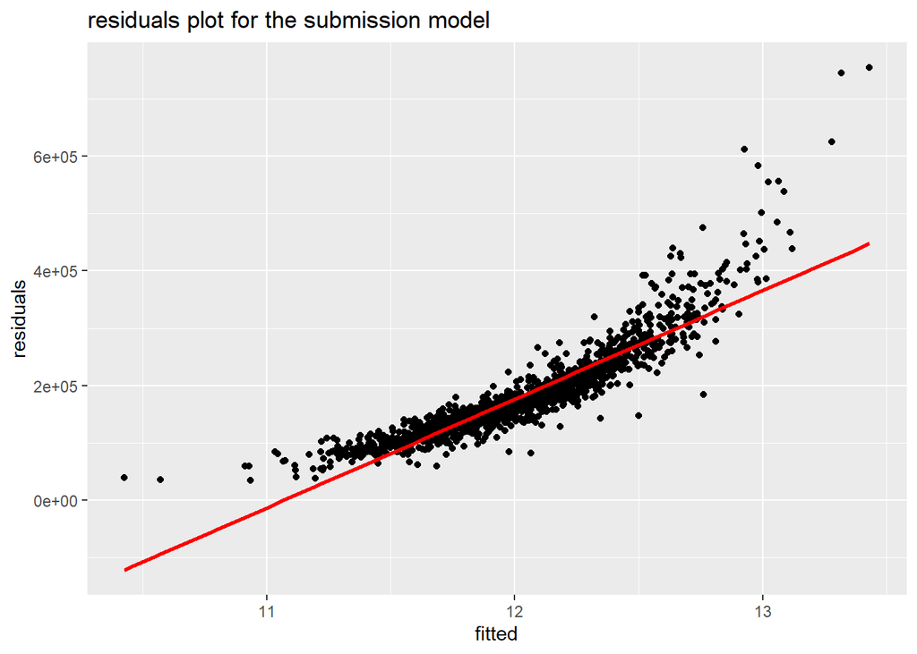

```r
train %>%
  mutate(fitted = fitted(submission_model),
         residuals = SalePrice - fitted) %>%
   ggplot(aes(fitted, residuals)) +
  geom_point() +
  geom_smooth(method = "lm", se = F, col = "red") +
  labs(title = "residuals plot for the submission model")
```

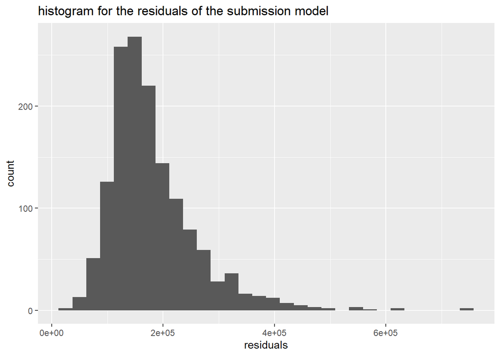

```r
train %>%
  mutate(fitted = fitted(submission_model),
         residuals = SalePrice - fitted) %>%
  ggplot(aes(x=residuals))+
  geom_histogram() +
  labs(title = "histogram for the residuals of the submission model")
```

> Submitting the submission file to the Kaggle will get the score of 0.17833.